# Predição de Votação de Deputados

Juan Barros

29 de outubro de 2018

Para iniciar a predição, é preciso limpar e tratar os dados para se adequarem aos modelos que utilizaremos. Como referência, usarei os parâmetros utilizados na [análise anterior](https://rpubs.com/JuanBarros/lab2). A seguir, realizo a importação e tratamento dos dados de treino disponível:

```r
dadosBrutos <- read.csv("train.csv") # Ao utilizar read_csv, o caret emite um erro
teste <- read.csv("test.csv") %>%
  mutate(comites = recursos_de_outros_candidatos.comites)
dadosLimpos <- dadosBrutos %>%
  mutate(comites = recursos_de_outros_candidatos.comites) %>%
  select(-sequencial_candidato, -uf, -partido, - estado_civil, -ano, -recursos_de_outros_candidatos.comites)
```

Para realizar o treino no modelo ridge, utilizarei o comando “train”" do caret para treinar meu modelo com o parâmetro “lambdas”, que descreve valores de lambda para a utilização no treino.

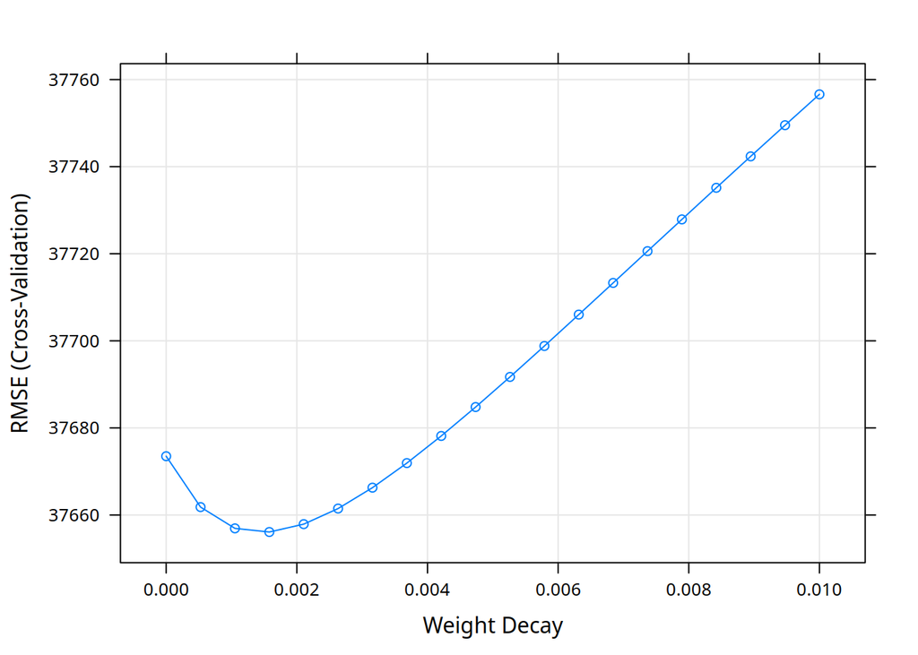

```r
lambdas <- expand.grid(lambda = seq(10^-2, 10^-9, length=20))

validacaoCruzada <- trainControl(method = "cv", number = 10)

ridgeModel <- train(votos ~ media_despesa + total_despesa + quantidade_fornecedores + quantidade_despesas + recursos_de_partido_politico + recursos_proprios + recursos_de_pessoas_juridicas + recursos_de_pessoas_fisicas + comites + media_receita + total_receita + quantidade_doadores + quantidade_doacoes, data = dadosLimpos,
                 method = "ridge",
                 tuneGrid = lambdas, preProc = c("center", "scale"),
                 trControl = validacaoCruzada)

plot(ridgeModel)
```

```r
ridgeModel
```

```
## Ridge Regression
##
## 7476 samples
##   13 predictor
##
## Pre-processing: centered (13), scaled (13)
## Resampling: Cross-Validated (10 fold)
## Summary of sample sizes: 6729, 6728, 6728, 6729, 6728, 6728, ...
## Resampling results across tuning parameters:
##
##   lambda        RMSE      Rsquared   MAE
##   0.0000000010  37673.50  0.4019662  16939.94
##   0.0005263167  37661.82  0.4021028  16941.23
##   0.0010526325  37656.93  0.4021510  16942.59
##   0.0015789482  37656.10  0.4021423  16943.76
##   0.0021052639  37657.90  0.4020951  16944.79
##   0.0026315797  37661.48  0.4020211  16945.95
##   0.0031578954  37666.28  0.4019286  16947.03
##   0.0036842112  37671.92  0.4018231  16947.91
##   0.0042105269  37678.15  0.4017086  16948.61
##   0.0047368426  37684.79  0.4015881  16949.16
##   0.0052631584  37691.71  0.4014637  16949.56
##   0.0057894741  37698.81  0.4013369  16949.83
##   0.0063157898  37706.02  0.4012089  16950.08
##   0.0068421056  37713.30  0.4010807  16950.22
##   0.0073684213  37720.59  0.4009530  16950.38
##   0.0078947371  37727.88  0.4008261  16950.47
##   0.0084210528  37735.14  0.4007006  16950.66
##   0.0089473685  37742.36  0.4005766  16951.09
##   0.0094736843  37749.52  0.4004544  16951.49
##   0.0100000000  37756.61  0.4003342  16951.88
##
## RMSE was used to select the optimal model using the smallest value.
## The final value used for the model was lambda = 0.001578948.
```

Para o modelo lasso, mudarei apenas o parâmetro que define o método e o range do lambda:

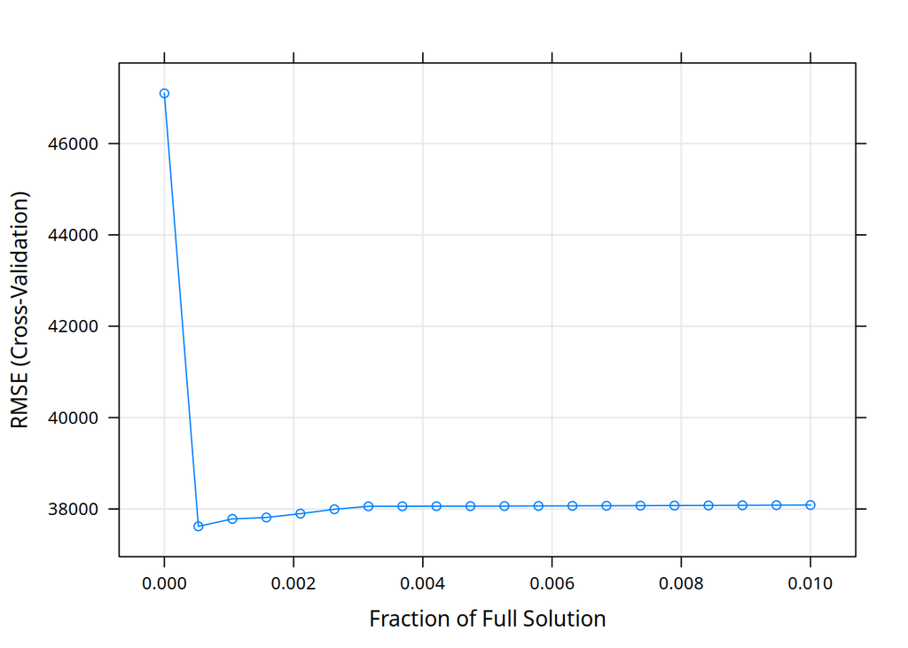

```r
lambdas <- expand.grid(fraction = seq(0.01, 10^-8, length=20))
lassoModel <- train(votos ~ media_despesa + total_despesa + quantidade_fornecedores + quantidade_despesas + recursos_de_partido_politico + recursos_proprios + recursos_de_pessoas_juridicas + recursos_de_pessoas_fisicas + comites + media_receita + total_receita + quantidade_doadores + quantidade_doacoes, data = dadosLimpos,
                 method = "lasso",
                 tuneGrid = lambdas,
                 preProc = c("center", "scale"),
                 trControl = validacaoCruzada)

plot(lassoModel)
```

```r
lassoModel
```

```
## The lasso
##
## 7476 samples
##   13 predictor
##
## Pre-processing: centered (13), scaled (13)
## Resampling: Cross-Validated (10 fold)
## Summary of sample sizes: 6728, 6728, 6731, 6729, 6728, 6728, ...
## Resampling results across tuning parameters:
##
##   fraction      RMSE      Rsquared   MAE
##   0.0000000100  47098.64  0.4002017  28612.91
##   0.0005263253  37619.61  0.4025253  19024.65
##   0.0010526405  37782.08  0.3947527  17158.42
##   0.0015789558  37813.38  0.3946483  16952.58
##   0.0021052711  37896.89  0.3929275  16938.79
##   0.0026315863  37992.80  0.3911995  16941.97
##   0.0031579016  38057.12  0.3900307  16947.02
##   0.0036842168  38058.49  0.3900017  16947.79
##   0.0042105321  38060.00  0.3899697  16948.56
##   0.0047368474  38061.64  0.3899345  16949.33
##   0.0052631626  38063.43  0.3898962  16950.10
##   0.0057894779  38065.35  0.3898547  16950.87
##   0.0063157932  38067.42  0.3898102  16951.64
##   0.0068421084  38069.62  0.3897626  16952.41
##   0.0073684237  38071.96  0.3897120  16953.18
##   0.0078947389  38074.45  0.3896584  16953.95
##   0.0084210542  38077.06  0.3896017  16954.72
##   0.0089473695  38079.82  0.3895421  16955.48
##   0.0094736847  38082.72  0.3894795  16956.25
##   0.0100000000  38085.75  0.3894140  16957.02
##
## RMSE was used to select the optimal model using the smallest value.
## The final value used for the model was fraction = 0.0005263253.
```

Por fim, no modelo KNN o parâmetro que indicará a quantidade de vizinhos será o k:

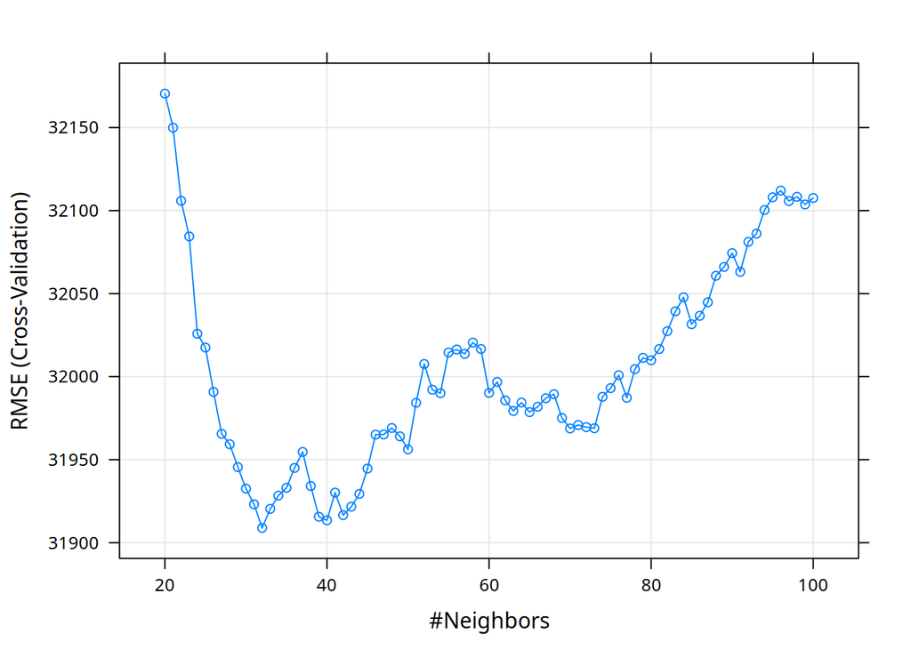

```r
k <- expand.grid(k = seq(20, 100, length=81)) # O pacote de treino lerá a coluna "k" para extrair o valor dos vizinhos

knnModel <- train(votos ~ media_despesa + total_despesa + quantidade_fornecedores + quantidade_despesas + recursos_de_partido_politico + recursos_proprios + recursos_de_pessoas_juridicas + recursos_de_pessoas_fisicas + comites + media_receita + total_receita + quantidade_doadores + quantidade_doacoes,
                     data = dadosLimpos,
                     method = "knn",
                     trControl = validacaoCruzada,
                     preProcess = c("center","scale"),
                     tuneGrid = k)

plot(knnModel)
```

```r
knnModel
```

```
## k-Nearest Neighbors
##
## 7476 samples
##   13 predictor
##
## Pre-processing: centered (13), scaled (13)
## Resampling: Cross-Validated (10 fold)
## Summary of sample sizes: 6728, 6728, 6728, 6728, 6728, 6729, ...
## Resampling results across tuning parameters:
##
##   k    RMSE      Rsquared   MAE
##    20  32170.45  0.5455151  12058.77
##    21  32149.94  0.5462156  12046.29
##    22  32105.92  0.5475360  12016.33
##    23  32084.45  0.5481497  12015.87
```

[output cut: 80 more lines]

# Compare os três modelos em termos do erro RMSE de validação cruzada

Ao realizar a mesma validação cruzada para os três modelos, obtive o menor valor pelo modelo KNN com seu melhor modelo. Em seguida vem o modelo lasso seguido pelo modelo ridge.

```r
summary(resamples(list(RIDGE= ridgeModel, LASSO = lassoModel, KNN = knnModel)))
```

```
##
## Call:
## summary.resamples(object = resamples(list(RIDGE = ridgeModel, LASSO
##  = lassoModel, KNN = knnModel)))
##
## Models: RIDGE, LASSO, KNN
## Number of resamples: 10
##
## MAE
##           Min.  1st Qu.   Median     Mean  3rd Qu.     Max. NA's
## RIDGE 15419.17 15861.24 17396.26 16943.76 17648.84 18378.49    0
## LASSO 16794.63 18327.96 18715.59 19024.65 19785.87 20979.59    0
## KNN   10824.17 11043.33 11576.07 11887.52 12406.59 14445.86    0
##
## RMSE
##           Min.  1st Qu.   Median     Mean  3rd Qu.     Max. NA's
## RIDGE 26705.22 29239.69 34579.93 37656.10 44718.87 60033.12    0
## LASSO 30913.10 31904.80 33938.77 37619.61 40949.28 57619.70    0
## KNN   23039.05 25263.44 29632.86 31908.88 35371.19 55902.50    0
##
## Rsquared
##            Min.   1st Qu.    Median      Mean   3rd Qu.      Max. NA's
## RIDGE 0.1645269 0.3136204 0.4578758 0.4021423 0.5134693 0.5610341    0
## LASSO 0.1963366 0.3795138 0.4225589 0.4025253 0.4638955 0.5062079    0
## KNN   0.3067104 0.4899696 0.5921922 0.5539527 0.6421980 0.6715653    0
```

# Quais as variáveis mais importantes segundo o modelo de regressão Ridge e Lasso? Variáveis foram descartadas pelo Lasso? Quais?

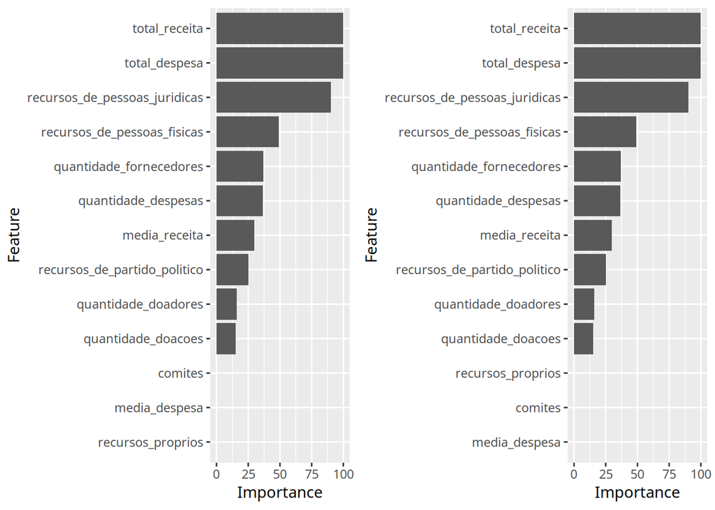

```r
ridgeImp <-ggplot(varImp(ridgeModel))
lassoImp <-ggplot(varImp(lassoModel))
grid.arrange(ridgeImp, lassoImp, nrow = 1)
```

Para as dois modelos, a variável total_despesa tem uma grande importância no modelo. Além disso, o modelo lasso eliminou as variáveis desnecessárias. As variáveis utilizadas como preditoras no modelo lasso podem ser obtidas com o comando abaixo:

```r
preditores <- predictors(lassoModel)
preditores
```

```
## [1] "total_despesa"                 "recursos_de_pessoas_juridicas"
## [3] "recursos_de_pessoas_fisicas"
```

Todas as outras variáveis foram eliminadas.

# Re-treine o melhor modelo (usando os melhores valores de parâmetros encontrados em todos os dados, sem usar validação cruzada)

Para retreinar, removerei todas as variáveis desnecessárias de acordo com o valor obtido na questão anterior.

```r
dadosAdaptados <- dadosLimpos %>%
  select(preditores, votos)
```

Em seguida, retreinarei o modelo knn tendo em vista seu baixo RMSE:

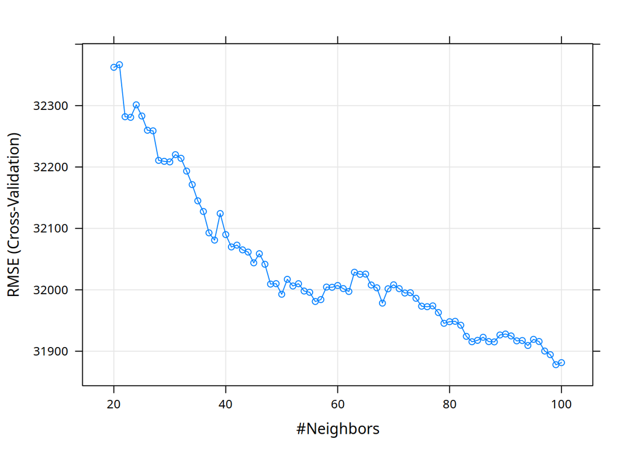

```r
knnModelMelhorado <- train(votos ~ .,
                     data = dadosAdaptados,
                     method = "knn",
                     trControl = validacaoCruzada,
                     preProcess = c("center","scale"),
                     tuneGrid = k)


plot(knnModelMelhorado)
```

```r
knnModelMelhorado
```

```
## k-Nearest Neighbors
##
## 7476 samples
##    3 predictor
##
## Pre-processing: centered (3), scaled (3)
## Resampling: Cross-Validated (10 fold)
## Summary of sample sizes: 6730, 6728, 6728, 6728, 6728, 6728, ...
## Resampling results across tuning parameters:
##
##   k    RMSE      Rsquared   MAE
##    20  32362.39  0.5409430  12224.51
##    21  32366.71  0.5405779  12227.30
##    22  32281.93  0.5427781  12184.59
##    23  32280.94  0.5427562  12182.47
```

[output cut: 80 more lines]

# Use esse último modelo treinado para prever os dados de teste disponíveis [no challenge que criamos na plataforma Kaggle](https://www.kaggle.com/c/ufcg-cdp-20182)

```r
previsao <- predict(knnModelMelhorado, teste)
resposta <- data.frame(ID= teste$sequencial_candidato, votos= previsao)
resposta$ID <- as.character(resposta$ID)
```